# Marine litter analysis

# 1 はじめに

東京海洋大学資源解析学研究室で作成した， 海ごみ解析パッケージ(malia)内で使用できる関数マニュアルです．

## 1.1 前提条件

R (>= 3.5.2)のバージョンであること， [Rtools](https://cran.r-project.org/bin/windows/Rtools/)がインストールされている必要があります．

## 1.2 インストール

```r
#install.packages("devtools")  #devtoolsをインストールしていない場合
#devtools::install_github("y-yasutomo/malia")　#パッケージのインストール
library(malia) #呼び出し
library(dplyr) #データハンドリングに便利
```

一連の解析手順マニュアル[簡易版](https://y-yasutomo.github.io/malia/)

## 1.3 参考文献

ライントランセクト法  
> Buckland, S.T. et al. (2015) Distance sampling: Methods and applications. Springer International Publishing, Switzerland.  
> Buckland, S.T. et al. (2001) Introduction to Distance Sampling. Oxford University Press, Oxford, United Kingdom.

# 2 解析手順

解析の手順としては次の段階がある．  
1. データ整形  
2. 推定  
3. 結果の統合，作図・作表

解析手順と関数関係:

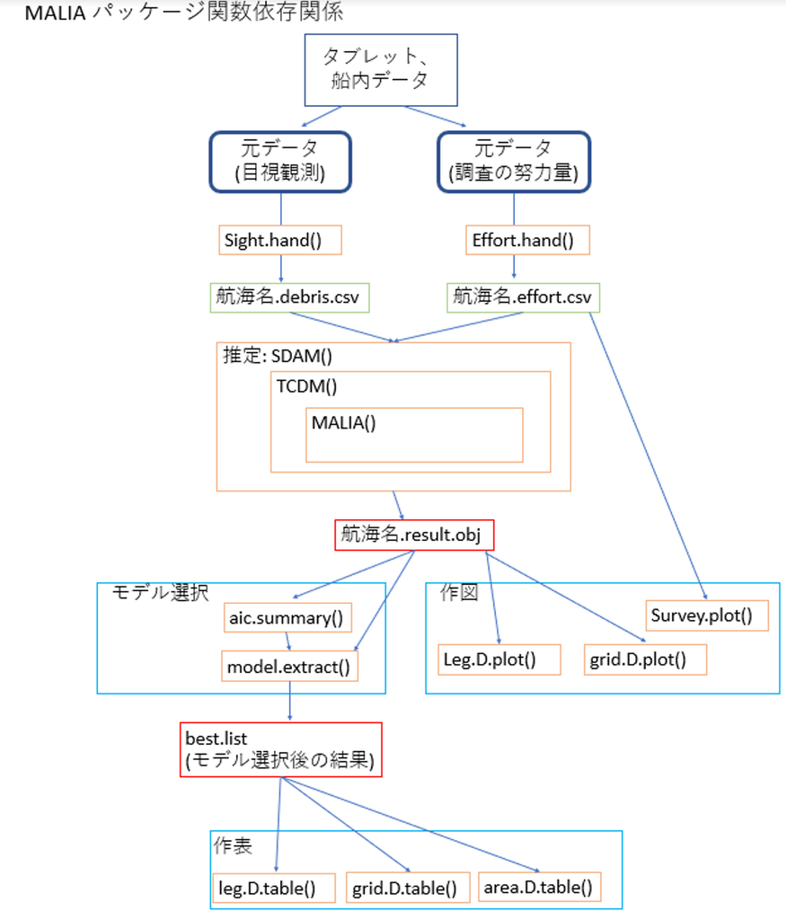

関数の依存関係

# 3 データ整形

タブレットデータは解析に用いる形に整形する必要があります.  
解析には**目視観測データ**と航海の**努力量データ**が必要となります．それぞれの整形には`Sight.hand()`,`Effort.hand()`関数を使います．

## 3.1 目視観測データ

`Sight.hand()`関数で目視観測データを解析に用いる形に整形できます.  
問題なく実行されると，作業ディレクトリに`Rev.name.debris`という名称のcsvファイルが作成されます.

```r
#データ(csvファイル)の名前を指定
Data.name<-"まとめ全データ"
#R内での名称(なんでもいい)
Rev.name<-"S19y1"
Sight.hand(Data.name,Rev.name)
```

データの確認

```r
head(read.csv("S19y1.debris.csv"))
```

|  | max | min | distance | leg.number | lat | lon | type | size | weather | occo | number |
| --- | --- | --- | --- | --- | --- | --- | --- | --- | --- | --- | --- |
| 1 | 10 | 5 | 7.5 | 1 | 35.03556 | 139.5551 | NO | S | O | 3 | 5 |
| 2 | 10 | 5 | 7.5 | 1 | 35.03008 | 139.5465 | PC | SS | O | 3 | 1 |
| 3 | 10 | 5 | 7.5 | 1 | 35.02787 | 139.5431 | EPS | SS | O | 3 | 1 |
| 4 | 5 | 0 | 2.5 | 1 | 35.02672 | 139.5412 | UO | SS | O | 3 | 1 |
| 5 | 10 | 5 | 7.5 | 1 | 35.02317 | 139.5357 | NO | SS | O | 3 | 1 |
| 6 | 20 | 15 | 17.5 | 1 | 35.02178 | 139.5336 | SW | S | O | 3 | 1 |

## 3.2 努力量データ

努力量データには`Effort.hand()`関数を使います．  
こちらは，作業ディレクトリに`Rev.name.effort`という名称のcsvファイルが作成されます.

```r
Data.name<-"レグ番号順"
Effort.hand(Data.name,Rev.name)
```

データの確認

```r
head(read.csv("S19y1.effort.csv"))
```

|  | leg.number | lat.start | lon.start | lat.end | lon.end | leg.length |
| --- | --- | --- | --- | --- | --- | --- |
| 1 | 1 | 35.04131 | 139.5642 | 34.95652 | 139.4288 | 15.53158 |
| 2 | 2 | 34.95652 | 139.4288 | 34.89214 | 139.3174 | 12.43461 |
| 3 | 3 | 34.32673 | 137.5644 | 34.26223 | 137.3203 | 23.58211 |
| 4 | 4 | 34.26223 | 137.3203 | 34.18926 | 137.0746 | 24.04288 |
| 5 | 5 | 34.18926 | 137.0746 | 34.12244 | 136.8223 | 24.42273 |
| 6 | 6 | 34.12244 | 136.8223 | 34.10081 | 136.7035 | 11.22015 |

# 4 解析

`malia`パッケージでは，ライントランセクト法に基づく密度推定を行えます． 発見関数は次の4種類のオプションがあります．

## 4.1 発見関数

### 4.1.1 Half normal

$$g(x)=exp(-\frac{x^2}{2\sigma^2})$$

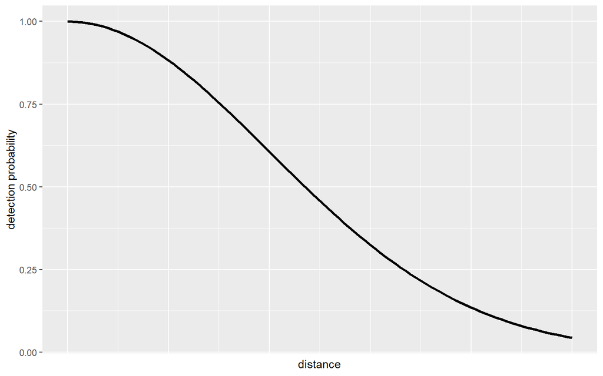

Figure 1: Half normal detection function

### 4.1.2 Hazard rate

$$g(x)=1-exp\left\{ \displaystyle -\left(\frac{x}{\sigma}\right)^{-b} \right\} \quad$$

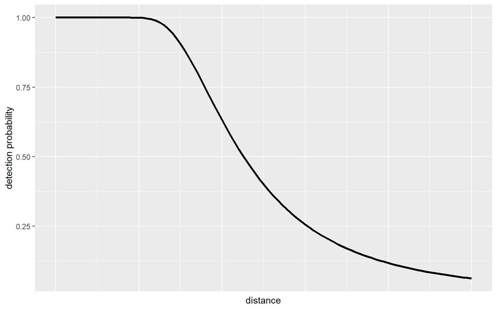

Figure 2: Hazard rate detection function

### 4.1.3 Half half normal

$$\begin{equation}
g(x) =
\begin{cases}
exp(-\frac{(x-cutpoint)^2}{2\delta^2}) \quad, & x \leq cutpoint \\
exp(-\frac{(x-cutpoint)^2}{2\sigma^2}) \quad, & x > cutpoint
\end{cases}
\end{equation}$$

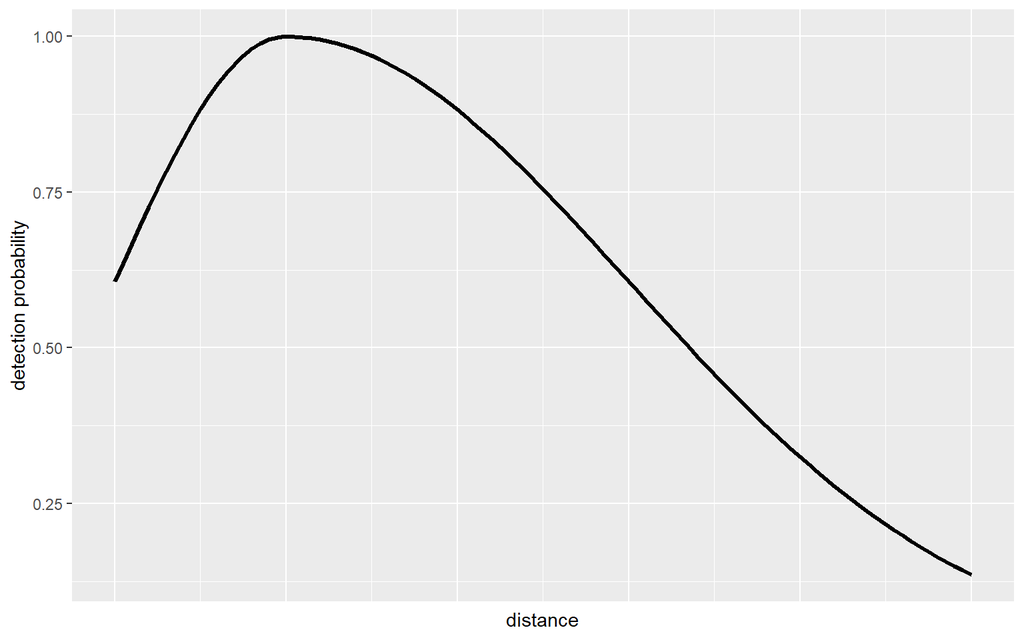

Figure 3: Half half normal detection function

### 4.1.4 Half hazard rate

$$\begin{equation}
g(x) =
\begin{cases}
exp(-\frac{(x-cutpoint)^2}{2\delta^2}) \quad, & x \leq cutpoint \\
1-exp\left\{ \displaystyle -\left(\frac{x-cutpoint}{\sigma}\right)^{-b} \right\} \quad, & x > cutpoint
\end{cases}
\end{equation}$$

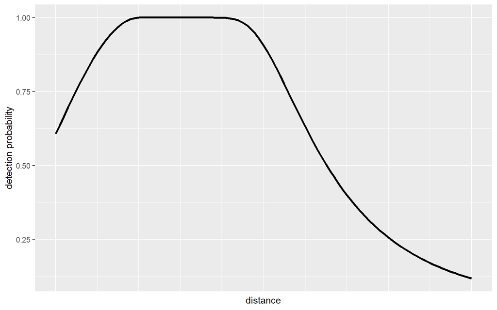

Figure 4: Half hazard rate detection function

## 4.2 発見関数とlegごとの密度推定

推定には，`MALIA()`関数が使えます.  
引数に**観測データ**と**努力量データ**, `key`で発見関数の型，`td`で最大目視距離を与えることで発見関数の推定と，leg,grid,areaごとの密度推定を行います.  
発見関数は  
`key="hn"` : *Harf normal*  
`key="hr"` : *Hazard rate*  
`key="hhn"` : *Harf half normal*  
`key="hhr"` : *Harf hazard rate*  
となります.

```r
Sight.Data<-malia::debris
Effort.Data<-malia::effort
td<-200
res<-MALIA(Sight.Data = Sight.Data,
           Effort.Data = Effort.Data,
           key = "hn",
           td = td)
```

```
## Start from 3973.39950231642
## ite 1 value = 2660.64454140305
## ite 2 value = 2660.64454140305
## generated initial value!
```

推定された発見関数の確認

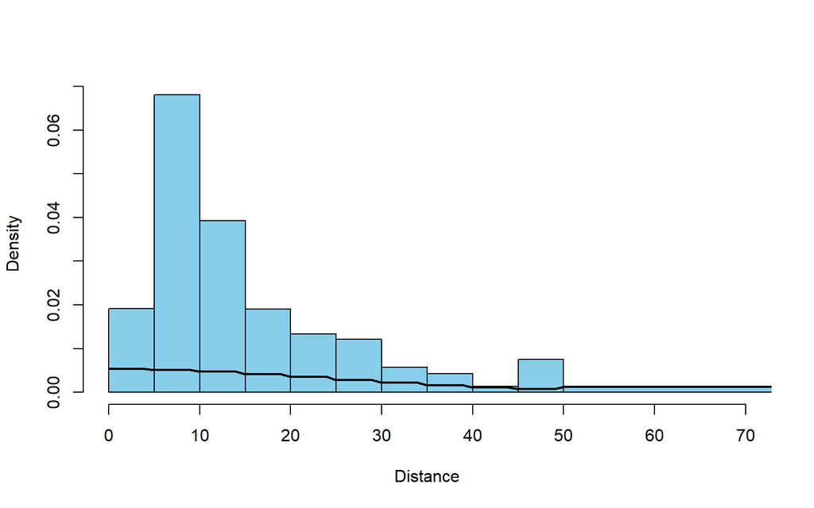

```r
hist(Sight.Data$distance,breaks = c(0, 5, 10, 15, 20, 25,
                                     30, 35, 40, 45, 50, 75, 100, 150, 200),xlim = c(0,70),col="skyblue",main="",xlab = "Distance")
 fx<-function(x,para){
   integrate(HN,x[1],x[2],para=para)$value/
     integrate(HN,0,200,para=para)$value
 }
 Breaks<-c(0, 5, 10, 15, 20, 25,
   30, 35, 40, 45, 50, 75, 100, 150, 200)
 ans<-numeric()
 for(i in 0:80){
   ind<-sum(Breaks<=i)
   ans[i+1]<-fx(c(Breaks[ind],Breaks[ind+1]),res$est$est.val)/
     integrate(HN,0,200,para=res$est$est.val)$value
 }
 points(0:80,ans,type="l",lwd=2)
```

## 4.3 gridの密度推定

`grid.D()`関数を使います.  
引数には，`MALIA()`関数の結果オブジェクトに格納されている，legごとの密度推定結果を使います.

```r
grid.D(res$leg.D.obs$leg.result)
```

| lat.min | lat.max | lon.min | lon.max | Density | Total.length |
| --- | --- | --- | --- | --- | --- |
| 33.0 | 33.5 | 132.0 | 132.5 | NaN | 0.000000 |
| 33.5 | 34.0 | 132.0 | 132.5 | 39.52102 | 24.125190 |
| 34.0 | 34.5 | 132.0 | 132.5 | NaN | 0.000000 |
| 34.5 | 35.0 | 132.0 | 132.5 | NaN | 0.000000 |
| 35.0 | 35.5 | 132.0 | 132.5 | NaN | 0.000000 |
| 35.5 | 36.0 | 132.0 | 132.5 | NaN | 0.000000 |
| 33.0 | 33.5 | 132.5 | 133.0 | NaN | 0.000000 |
| 33.5 | 34.0 | 132.5 | 133.0 | 121.08797 | 22.293153 |
| 34.0 | 34.5 | 132.5 | 133.0 | 99.04803 | 23.899421 |
| 34.5 | 35.0 | 132.5 | 133.0 | NaN | 0.000000 |

[output cut: 80 more lines]

## 4.4 areaの密度推定

`area.D()`関数を使います.  
引数には，`MALIA()`関数の結果オブジェクトに格納されている，legごとの密度推定結果を使います.

```r
area.D(res$leg.D.obs$leg.result)
```

```
## $area.density
##    Area   Density Total.Length
## 1     1       NaN        0.000
## 2     2       NaN        0.000
## 3     3       NaN        0.000
## 4     4       NaN        0.000
## 5     5       NaN        0.000
## 6     6       NaN        0.000
## 7     7       NaN        0.000
## 8     8       NaN        0.000
## 9     9 149.07025      225.183
## 10   10       NaN        0.000
## 11   11       NaN        0.000
## 12   12  40.75428      163.766
## 13   13       NaN        0.000
```

[output cut: 27 more lines]

## 4.5 一航海分の解析

`MALIA()`関数では，与えたデータすべてを用いて発見関数を推定する．`SDAM()`関数は観測データのごみの種類，発見関数，共変量なし・共変量(occo,weather,size)ごと  
つまり，一種類のごみに対して16通りの推定を行います．  
計算には30-60分程度時間がかかります.  
計算が終了すると,作業ディレクトリに`航海名.result.obj`というファイルが作成されます．  
以降は，既に作成された結果を用いて結果のハンドリングを行います.

```r
#res<-SDAM(Voyage.name=Voyage.name,Sight.Data=Sight.Data,Effort.Data=Effort.Data,COVARIATE = c("conv", "occo","weather", "size"), key.list = c("hn","hr", "hhn", "hhr"),td=200,cp=10)
```

# 5 モデル選択と結果の抽出

`SDAM()`関数の結果オブジェクトの読み込み.

```r
res<-readRDS("S19y1.result.obj")
```

`aic.summary()`関数で，ごみの種類ごとに一覧の結果を返します.  
種類*EPS*の結果.

```r
 aic.mat<-aic.summary(result.obj = res)
 aic.mat$EPS
```

| Key | Covariate | AIC |
| --- | --- | --- |
| hn | conv | 1116.1415 |
| hr | conv | 2770.8769 |
| hhn | conv | 1137.1496 |
| NA | NA | NA |
| hn | occo | 1111.9064 |
| hr | occo | 1053.7753 |
| hhn | occo | 1130.8324 |
| hhr | occo | 1030.1050 |
| hn | weather | 1109.1243 |
| hr | weather | 1053.4825 |

[output cut: 6 more lines]

`model.extract()`関数を使えば，すべてのごみについてAICによって選択されたモデルを抽出できます. 引数には，`aic.summary()`関数の結果オブジェクトと航海の解析結果のオブジェクトを与えます．

```r
 best.model<-model.extract(aic.mat = aic.mat,result.obj = res)
 best.model$best.mat
```

|  | Key | Covariate | AIC |
| --- | --- | --- | --- |
| DW | hhn | weather | 420.349858 |
| EPS | hhr | size | 914.248092 |
| FGF | hn | size | 133.406464 |
| FGN | hhr | conv | 32.564444 |
| FGO | hhn | size | 42.360619 |
| FP | hhr | size | 610.382554 |
| G | hr | size | 9.484621 |
| M | hhr | conv | 94.105375 |
| NO | hhr | weather | 689.463054 |
| PBA | hhn | occo | 330.993705 |

[output cut: 6 more lines]

# 6 作図

作図用には次の関数があります.  
`survey.plot()` : 航跡図  
`leg.D.plot()` : legごとの密度推定結果  
`grid.D.plot()` : gridごとの密度推定結果

## 6.1 航跡図

航跡図の作図には，`survey.plot()`関数が使えます．  
引数には，**努力量データ**を与えます．

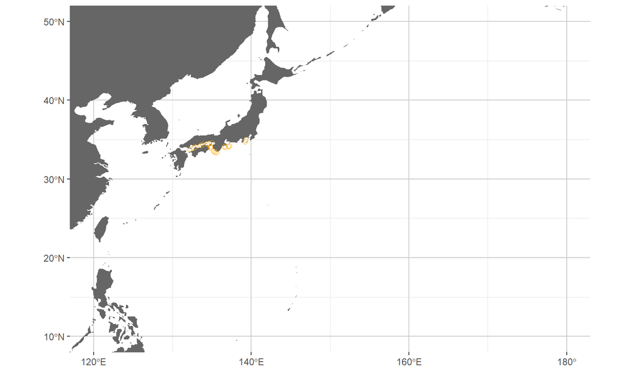

```r
survey.plot(Effort.Data = Effort.Data)
```

引数の`xl`,`yl`を変えれば，描画範囲を選択できます.  
デフォルトは`xl = c(120, 180)`,`yl = c(10, 50)`となっています.

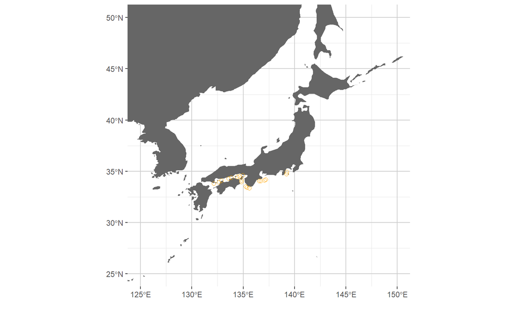

```r
survey.plot(Effort.Data = Effort.Data,
            xl = c(125,150),
            yl = c(25,50))
```

## 6.2 leg

`leg.D.plot()`関数が使えます.  
引数には，`MALIA()`関数の結果からlegごとの推定値の結果を抽出したものを与えます．

```r
res<-MALIA(Sight.Data = Sight.Data,
           Effort.Data = Effort.Data,
           key = "hn",
           td = td)
```

```
## Start from 3973.39950231642
## ite 1 value = 2660.64454140305
## ite 2 value = 2660.64454140305
## generated initial value!
```

legごとの密度推定結果

```r
res$leg.D.obs$leg.result
```

| Leg.No. | Density | Abundance | Detected.Number | Leg.Length | Lat.Start | Lon.Start | Lat.End | Lon.End |
| --- | --- | --- | --- | --- | --- | --- | --- | --- |
| 1 | 46.13634 | 821.9413 | 25 | 17.81548 | 34.22011 | 137.2803 | 34.16826 | 137.0974 |
| 2 | 80.68412 | 821.9413 | 25 | 10.18715 | 34.16826 | 137.0974 | 34.10973 | 137.0123 |
| 3 | 97.16820 | 1709.6380 | 52 | 17.59462 | 34.12495 | 136.7982 | 34.04033 | 136.6369 |
| 4 | 48.51237 | 854.8190 | 26 | 17.62064 | 34.04033 | 136.6369 | 34.10243 | 136.4612 |
| 5 | 23.47864 | 361.6542 | 11 | 15.40354 | 33.91543 | 134.8557 | 34.03701 | 134.7751 |
| 6 | 127.62128 | 2728.8452 | 83 | 21.38237 | 34.07920 | 134.7292 | 34.18823 | 134.9203 |
| 7 | 230.07250 | 3879.5630 | 118 | 16.86235 | 34.61295 | 135.0398 | 34.58147 | 134.8600 |
| 8 | 234.89176 | 5391.9351 | 164 | 22.95498 | 34.55104 | 134.7499 | 34.47385 | 134.5180 |
| 9 | 228.90738 | 5359.0574 | 163 | 23.41147 | 34.47385 | 134.5180 | 34.42164 | 134.2712 |
| 10 | 229.03863 | 5819.3446 | 177 | 25.40770 | 34.41606 | 133.9551 | 34.34278 | 133.6933 |

[output cut: 9 more lines]

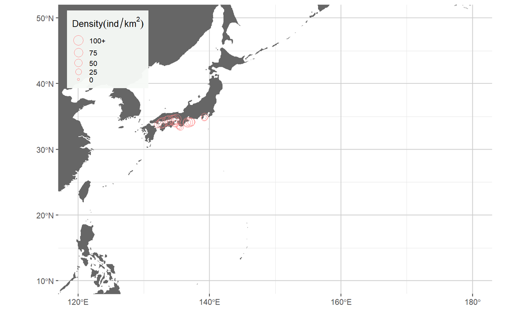

Figure 5: legごとの密度推定結果

```r
leg.D.plot(res$leg.D.obs$leg.result)
```

同様に引数の`xl`,`yl`を変えれば，描画範囲を選択できます.  
デフォルトは`xl = c(120, 180)`,`yl = c(10, 50)`となっています.  
また，引数の`Type`に文字列を与えると図中に表示することができます.

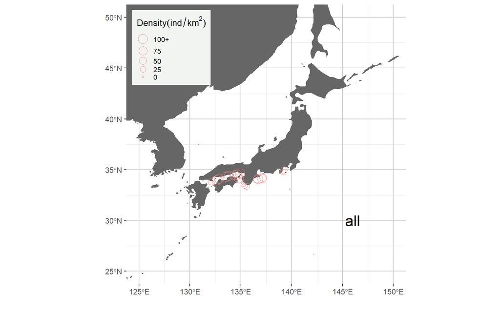

Figure 6: legごとの密度推定結果2

```r
leg.D.plot(res$leg.D.obs$leg.result,
           xl = c(125,150),
           yl = c(25,50),
           Type = "all")
```

## 6.3 grid

`grid.D.plot()`関数が使えます.  
引数には，`grid.D()`関数の結果を与えます.

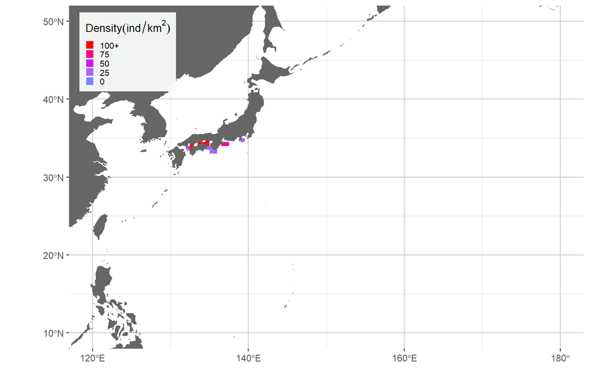

Figure 7: gridごとの密度推定結果

```r
grid.D.res<-grid.D(res$leg.D.obs$leg.result)
grid.D.plot(grid.D.res = grid.D.res)
```

引数は`leg.D.plot()`関数と同様に変更できます.

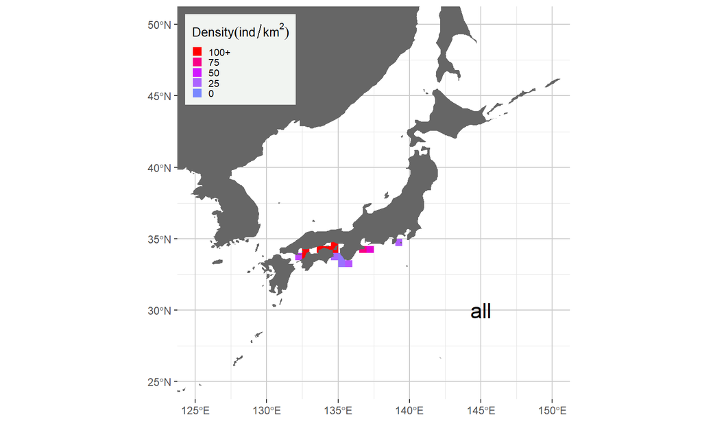

Figure 8: gridごとの密度推定結果2

```r
grid.D.plot(grid.D.res = grid.D.res,
            xl = c(125,150),
            yl = c(25,50),
           Type = "all")
```

# 7 複数航海の描画

## 7.1 航跡図

データの読み込み  
複数航海を同時にプロットしたい場合，努力量データに`voyage_name`という列を追加します．

```r
Data1<-read.csv("S19y1.effort.csv") %>%
   mutate(.,voyage_name = "S19y1")
Data2<-read.csv("U19y1.effort.csv") %>%
   mutate(.,voyage_name = "U19y1")
```

データを縦に結合する

```r
Data<-rbind(Data1,Data2)
```

プロットには，`survey.plot()`関数が使えます．この時，引数の`multi=T`とします．(デフォルトでは`multi=F`)

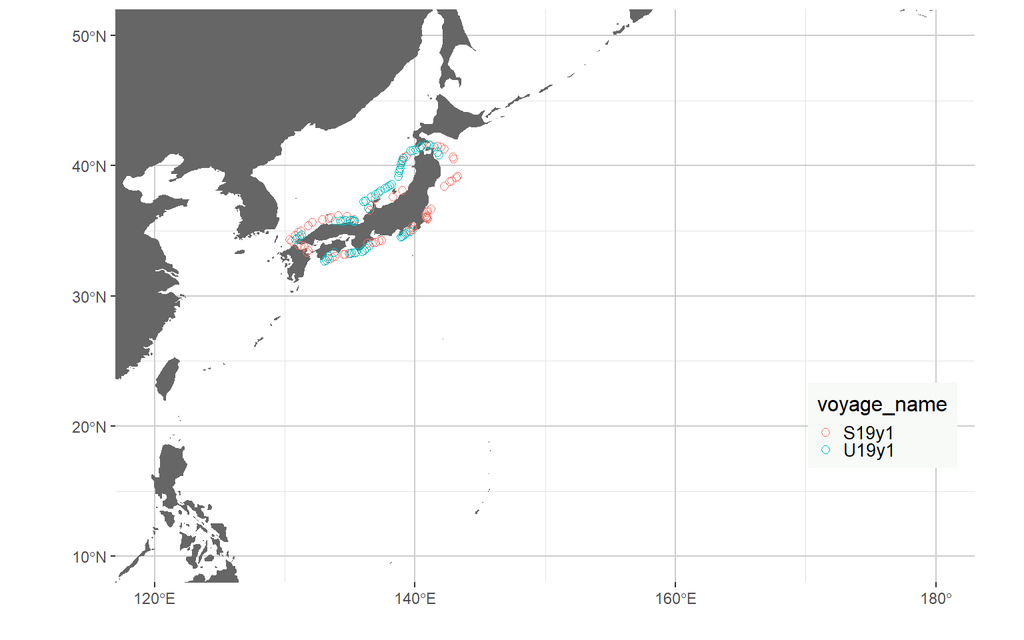

```r
survey.plot(Data,multi = T)
```

`multi=F`とすると，一つの航海として扱われます.

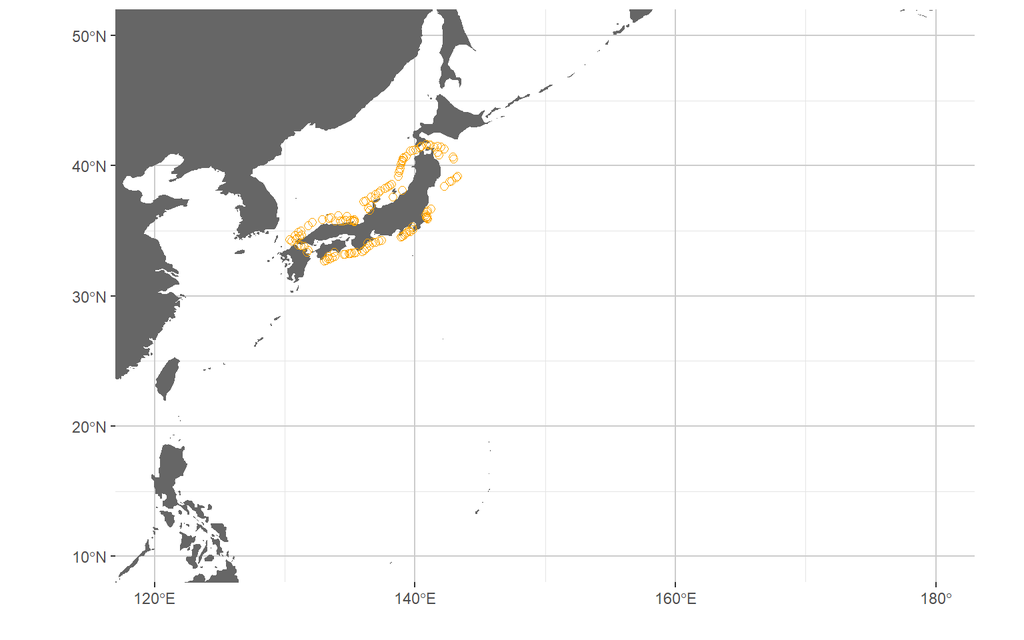

```r
survey.plot(Data,multi = F)
```

## 7.2 leg

複数航海の結果を同時にプロットしたい場合でも，`leg.D.plot()`関数が使えます.  
legごとの推定値の結果を縦に結合し，引数に与えます．

データ用意

```r
#'S19y1で推定'
 res1<-MALIA(Sight.Data = read.csv("S19y1.debris.csv"),
             Effort.Data = read.csv("S19y1.effort.csv"),
             key="hn",td=200)
```

```
## Start from 8917.63166023761
## ite 1 value = 5597.06850886512
## ite 2 value = 5597.06850886512
## generated initial value!
```

```r
#'U19y1で推定'
 res2<-MALIA(Sight.Data = read.csv("U19y1.debris.csv"),
             Effort.Data = read.csv("U19y1.effort.csv"),
             key="hn",td=200)
```

```
## Start from 9245.72635954634
## ite 1 value = 6535.91522660305
## ite 2 value = 6535.91522660305
## generated initial value!
```

```r
#legごとの推定結果をくっつける
 tmp<-rbind(res1$leg.D.obs$leg.result,res2$leg.D.obs$leg.result)
```

プロットする

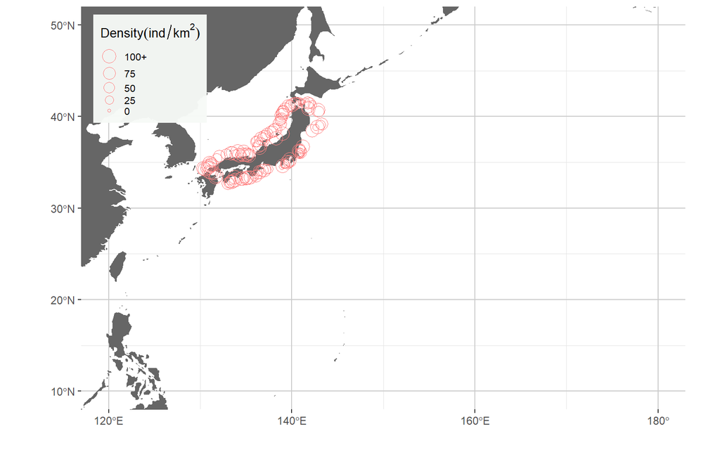

Figure 9: 複数航海のlegごとの密度推定結果

```r
 leg.D.plot(tmp)
```

## 7.3 grid

複数航海のlegごとの密度推定結果をもとに，gridごとの密度を計算します．計算には`grid.D()`関数が使えます.  
この時，先ほどのlegごとの推定値の結果を縦に結合したものを引数に与えます．

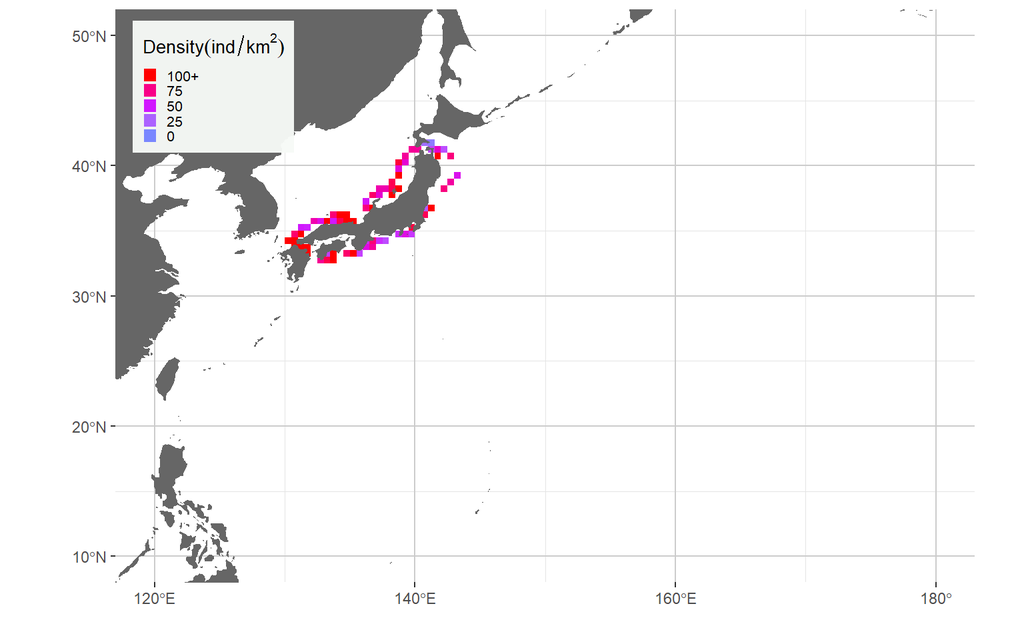

Figure 10: 複数航海のgridごとの密度推定結果

```r
 grid.res<-grid.D(tmp)
 grid.D.plot(grid.res)
```

# 8 作表

作表には  
`survey.inf()`  
`leg.D.table()`  
`grid.D.table()`  
`area.D.table()`  
関数が使えます．

## 8.1 航海の情報

`survey.inf()`関数は引数に**観測データ**と**努力量データ**,`Artificial`,`Natural`にそれぞれ人工物・天然物の文字列を与えることで，航海の要約を行えます．  
なお，`Artificial`には`"FGN","FGF","FGO","EPS","PBA","PBO","FP","PC","G","M","W","UO"`，  
`Natural`には`"SW","DW","NO"`がデフォルトで与えられています.

```r
args(survey.inf)
```

```
## function (Sight.Data, Effort.Data, Artificial = c("FGN", "FGF",
##     "FGO", "EPS", "PBA", "PBO", "FP", "PC", "G", "M", "W", "UO"),
##     Natural = c("SW", "DW", "NO"))
## NULL
```

```r
survey.info <- survey.inf(Sight.Data = Sight.Data,
           Effort.Data = Effort.Data)
survey.info$voyage.inf
```

| Number_of_legs | Total_leg_length | Number_of_debris |
| --- | --- | --- |
| 19 | 388.9489 | 3470 |

```r
survey.info$debris.inf
```

|  | Number |
| --- | --- |
| DW | 178 |
| EPS | 711 |
| FGF | 10 |
| FGN | 7 |
| FGO | 2 |
| FP | 95 |
| M | 11 |
| NO | 223 |
| PBA | 150 |
| PBO | 132 |

[output cut: 7 more lines]

## 8.2 leg

調査レグごとの密度推定結果  
モデル選択と結果の抽出で用いた`model.extract()`関数の結果オブジェクトを引数に使います． それぞれのごみについて，選択されたモデルで作表します.

```r
 leg.table<-leg.D.table(best.model$best.list)
 head(leg.table)
```

|  | Voyage_name | Leg.No. | Leg.Length | DW_Density | DW_Abundance | DW_Detected.Number | EPS_Density | EPS_Abundance | EPS_Detected.Number | FGF_Density | FGF_Abundance | FGF_Detected.Number | FGN_Density | FGN_Abundance | FGN_Detected.Number | FGO_Density | FGO_Abundance | FGO_Detected.Number | FP_Density | FP_Abundance | FP_Detected.Number | G_Density | G_Abundance | G_Detected.Number | M_Density | M_Abundance | M_Detected.Number | NO_Density | NO_Abundance | … |
| --- | --- | --- | --- | --- | --- | --- | --- | --- | --- | --- | --- | --- | --- | --- | --- | --- | --- | --- | --- | --- | --- | --- | --- | --- | --- | --- | --- | --- | --- | --- |
| 1 | S19y1 | 1 | 15.53158 | 0.000000 | 0.00000 | 0 | 2.875913 | 44.66748 | 1 | 0.0000000 | 0.00000 | 0 | 0.000000 | 0.00000 | 0 | 0.00000 | 0.0000 | 0 | 10.113740 | 157.08237 | 4 | 0 | 0 | 0 | 0.0000000 | 0.00000 | 0 | 111.319444 | 1728.96695 | … |
| 2 | S19y1 | 2 | 12.43461 | 0.000000 | 0.00000 | 0 | 7.184382 | 89.33496 | 2 | 0.0000000 | 0.00000 | 0 | 0.000000 | 0.00000 | 0 | 0.00000 | 0.0000 | 0 | 2.507842 | 31.18403 | 1 | 0 | 0 | 0 | 0.0000000 | 0.00000 | 0 | 5.149807 | 64.03581 | … |
| 3 | S19y1 | 3 | 23.58211 | 1.714606 | 40.43403 | 1 | 3.788251 | 89.33496 | 2 | 0.0000000 | 0.00000 | 0 | 0.000000 | 0.00000 | 0 | 0.00000 | 0.0000 | 0 | 4.016363 | 94.71431 | 2 | 0 | 0 | 0 | 0.0000000 | 0.00000 | 0 | 5.430880 | 128.07163 | … |
| 4 | S19y1 | 4 | 24.04288 | 1.681746 | 40.43403 | 1 | 2.932572 | 70.50748 | 2 | 0.0000000 | 0.00000 | 0 | 0.000000 | 0.00000 | 0 | 0.00000 | 0.0000 | 0 | 1.969695 | 47.35716 | 1 | 0 | 0 | 0 | 0.0000000 | 0.00000 | 0 | 7.990200 | 192.10744 | … |
| 5 | S19y1 | 5 | 24.42273 | 4.966771 | 121.30209 | 3 | 0.000000 | 0.00000 | 0 | 0.5929212 | 14.48075 | 1 | 1.681239 | 41.06045 | 1 | 12.19099 | 297.7373 | 1 | 3.830534 | 93.55208 | 3 | 0 | 0 | 0 | 0.9234812 | 22.55393 | 1 | 20.975812 | 512.28651 | … |
| 6 | S19y1 | 6 | 11.22015 | 3.603697 | 40.43403 | 1 | 3.981005 | 44.66748 | 1 | 0.0000000 | 0.00000 | 0 | 0.000000 | 0.00000 | 0 | 0.00000 | 0.0000 | 0 | 5.558575 | 62.36806 | 2 | 0 | 0 | 0 | 0.0000000 | 0.00000 | 0 | 5.707215 | 64.03581 | … |

## 8.3 grid

グリッドごとの密度推定結果

```r
 grid.table<-grid.D.table(best.model$best.list)
 head(grid.table)
```

|  | Voyage_name | lat.min | lat.max | lon.min | lon.max | Total.length | DW_Density | EPS_Density | FGF_Density | FGN_Density | FGO_Density | FP_Density | G_Density | M_Density | NO_Density | PBA_Density | PBO_Density | PC_Density | SW_Density | UK_Density | UO_Density | W_Density |
| --- | --- | --- | --- | --- | --- | --- | --- | --- | --- | --- | --- | --- | --- | --- | --- | --- | --- | --- | --- | --- | --- | --- |
| 5 | S19y1 | 34.0 | 34.5 | 130.0 | 130.5 | 28.951574 | 8.609595 | 12.5512563 | 0.0000000 | 1.418246 | 0 | 10.610579 | 0.0000000 | 0.0000000 | 6.9653988 | 5.065174 | 1.1662469 | 36.27185 | 118.67336 | 0 | 2.887364 | 3.680957 |
| 24 | S19y1 | 33.5 | 34.0 | 130.5 | 131.0 | 8.050432 | 2.120540 | 10.3048629 | 0.7570482 | 0.000000 | 0 | 4.967238 | 0.0000000 | 1.1828279 | 57.0914721 | 1.950595 | 3.3142530 | 48.22086 | 21.10097 | 0 | 2.912438 | 0.000000 |
| 25 | S19y1 | 34.0 | 34.5 | 130.5 | 131.0 | 10.667411 | 26.204710 | 4.4270163 | 0.0000000 | 0.000000 | 0 | 14.080775 | 0.0000000 | 0.0000000 | 0.0000000 | 3.686272 | 1.1371805 | 57.49069 | 218.32117 | 0 | 1.706048 | 3.589216 |
| 26 | S19y1 | 34.5 | 35.0 | 130.5 | 131.0 | 28.054748 | 1.152343 | 0.7087753 | 0.5161605 | 0.000000 | 0 | 3.171910 | 0.0000000 | 0.0000000 | 0.6033223 | 4.474442 | 0.4203732 | 18.82814 | 96.00757 | 0 | 0.000000 | 1.290843 |
| 44 | S19y1 | 33.5 | 34.0 | 131.0 | 131.5 | 48.017979 | 1.422570 | 19.7272837 | 0.6414052 | 0.000000 | 0 | 15.657380 | 0.5793108 | 0.7935036 | 41.1072838 | 2.857713 | 4.1590517 | 50.84003 | 48.43197 | 0 | 2.488821 | 4.609253 |
| 46 | S19y1 | 34.5 | 35.0 | 131.0 | 131.5 | 17.481027 | 4.461982 | 2.7444465 | 0.0000000 | 0.000000 | 0 | 5.745742 | 0.0000000 | 0.0000000 | 2.3361226 | 2.213994 | 1.6277258 | 22.69685 | 124.44252 | 0 | 0.000000 | 0.000000 |

## 8.4 area

海区ごとの密度推定結果

```r
 area.table<-area.D.table(best.model$best.list)
 head(area.table)
```

|  | Voyage_name | Area | Total.Length | DW_Density | EPS_Density | FGF_Density | FGN_Density | FGO_Density | FP_Density | G_Density | M_Density | NO_Density | PBA_Density | PBO_Density | PC_Density | SW_Density | UK_Density | UO_Density | W_Density |
| --- | --- | --- | --- | --- | --- | --- | --- | --- | --- | --- | --- | --- | --- | --- | --- | --- | --- | --- | --- |
| 1 | S19y1 | 1 | 0.00000 | NaN | NaN | NaN | NaN | NaN | NaN | NaN | NaN | NaN | NaN | NaN | NaN | NaN | NaN | NaN | NaN |
| 2 | S19y1 | 2 | 0.00000 | NaN | NaN | NaN | NaN | NaN | NaN | NaN | NaN | NaN | NaN | NaN | NaN | NaN | NaN | NaN | NaN |
| 3 | S19y1 | 3 | 0.00000 | NaN | NaN | NaN | NaN | NaN | NaN | NaN | NaN | NaN | NaN | NaN | NaN | NaN | NaN | NaN | NaN |
| 4 | S19y1 | 4 | 32.70094 | 0.000000 | 1.844959 | 0.06774278 | 0.0000000 | 0.0000000 | 0.4971892 | 0 | 0.000000 | 2.791547 | 0.3992405 | 0.000000 | 3.020293 | 12.47068 | 3.026626 | 1.671151 | 0.0000000 |
| 5 | S19y1 | 5 | 254.49150 | 2.728150 | 8.360927 | 0.95391846 | 0.1613431 | 1.0020089 | 5.3827765 | 0 | 0.177247 | 2.691317 | 2.0581448 | 1.430220 | 26.520116 | 80.63864 | 1.555628 | 3.714848 | 0.9961041 |
| 6 | S19y1 | 6 | 183.07380 | 6.583154 | 3.542492 | 0.30356333 | 0.2242836 | 0.7851787 | 4.0103087 | 0 | 0.000000 | 7.484542 | 3.1204289 | 1.475264 | 21.456975 | 64.84430 | 4.590092 | 6.665154 | 0.3956250 |

# 9 人工物・天然物の合算

`ls.()`関数が使えます．  
引数の`leg.table`には,`leg.D.table()`関数の結果オブジェクト，`Ar`,`Nt`にそれぞれ人工物・天然物の文字列を与えます. なお，`Ar`には`"FGN","FGF","FGO","EPS","PBA","PBO","FP","PC","G","M","W","UO"`，  
`Nt`には`"SW","DW","NO"`がデフォルトで与えられています.

```r
 An.table<-ls.(leg.table = leg.table)
 head(An.table)
```

|  | Voyage_name | Leg.No. | Leg.Length | Lat.Start | Lon.Start | Lat.End | Lon.End | Artificial_Number | Artificial_Density | Natural_Number | Natural_Density |
| --- | --- | --- | --- | --- | --- | --- | --- | --- | --- | --- | --- |
| 1 | S19y1 | 1 | 15.53158 | 35.04131 | 139.5642 | 34.95652 | 139.4288 | 21 | 64.58159 | 34 | 145.932626 |
| 2 | S19y1 | 2 | 12.43461 | 34.95652 | 139.4288 | 34.89214 | 139.3174 | 10 | 38.76693 | 2 | 12.353263 |
| 3 | S19y1 | 3 | 23.58211 | 34.32673 | 137.5644 | 34.26223 | 137.3203 | 19 | 38.95511 | 3 | 7.145487 |
| 4 | S19y1 | 4 | 24.04288 | 34.26223 | 137.3203 | 34.18926 | 137.0746 | 19 | 31.06039 | 7 | 19.608936 |
| 5 | S19y1 | 5 | 24.42273 | 34.18926 | 137.0746 | 34.12244 | 136.8223 | 37 | 80.40501 | 16 | 40.619616 |
| 6 | S19y1 | 6 | 11.22015 | 34.12244 | 136.8223 | 34.10081 | 136.7035 | 16 | 52.56989 | 4 | 18.603033 |

この表には，legごとの人工物・天然物の密度推定結果が格納されていることになるので，これまでのようにlegごとの密度推定結果の作図，gridごとの密度推定結果の作図を行えます．

## 9.1 人工物

### 9.1.1 leg

人工物の結果だけを取り出す

```r
 Artificial.leg <- An.table %>% select(Leg.No.,Leg.Length,Lat.Start,Lon.Start,Lat.End,Lon.End,Artificial_Density) %>% rename(Density=Artificial_Density)
```

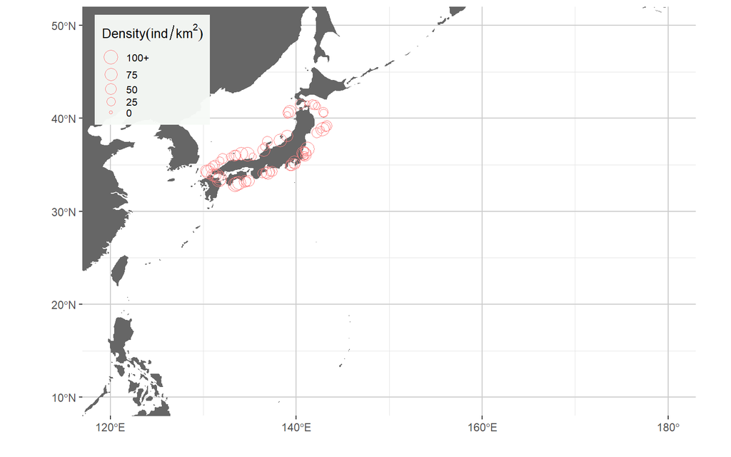

Figure 11: legごとの密度推定結果(人工物)

```r
leg.D.plot(Artificial.leg)
```

### 9.1.2 grid

まず，`grid.D()`関数で，gridごとの密度を計算します． 引数には，人工物のlegごとの密度推定結果が入った`Artificial.leg`をつかっていることに注意してください．

```r
 Artificial.grid<-grid.D(Artificial.leg)
```

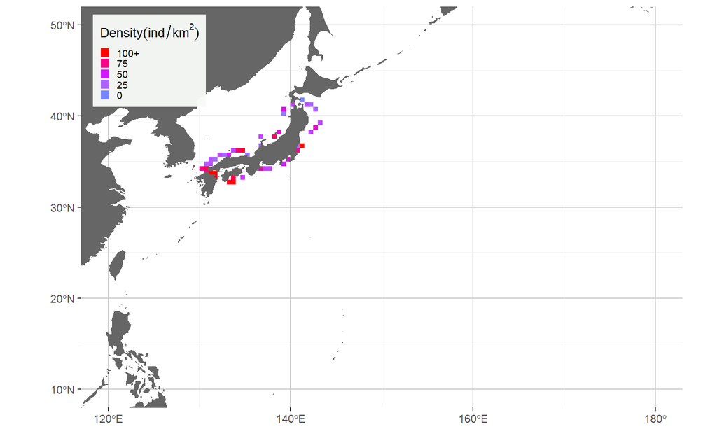

Figure 12: gridごとの密度推定結果(人工物)

```r
 grid.D.plot(Artificial.grid)
```

## 9.2 天然物

### 9.2.1 leg

人工物の時と同様の手順です． まず，天然物の結果だけを取り出します．

```r
 Natural.leg <- An.table %>% select(Leg.No.,Leg.Length,Lat.Start,Lon.Start,Lat.End,Lon.End,Natural_Density) %>% rename(Density=Natural_Density)
```

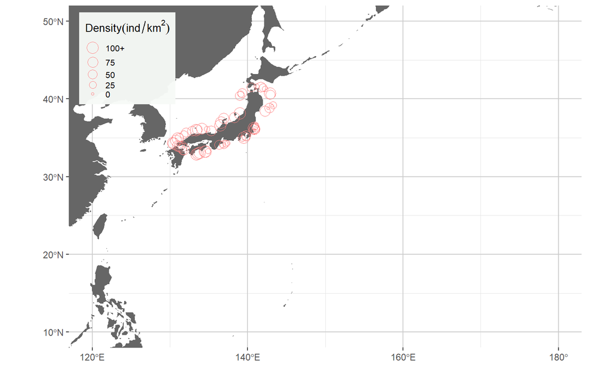

Figure 13: legごとの密度推定結果(天然物)

```r
leg.D.plot(Natural.leg)
```

### 9.2.2 grid

`grid.D()`関数で，gridごとの密度を計算します． 今回，引数には天然物のlegごとの密度推定結果が入った`Natural.leg`をつかっています．

```r
 Natural.grid<-grid.D(Natural.leg)
```

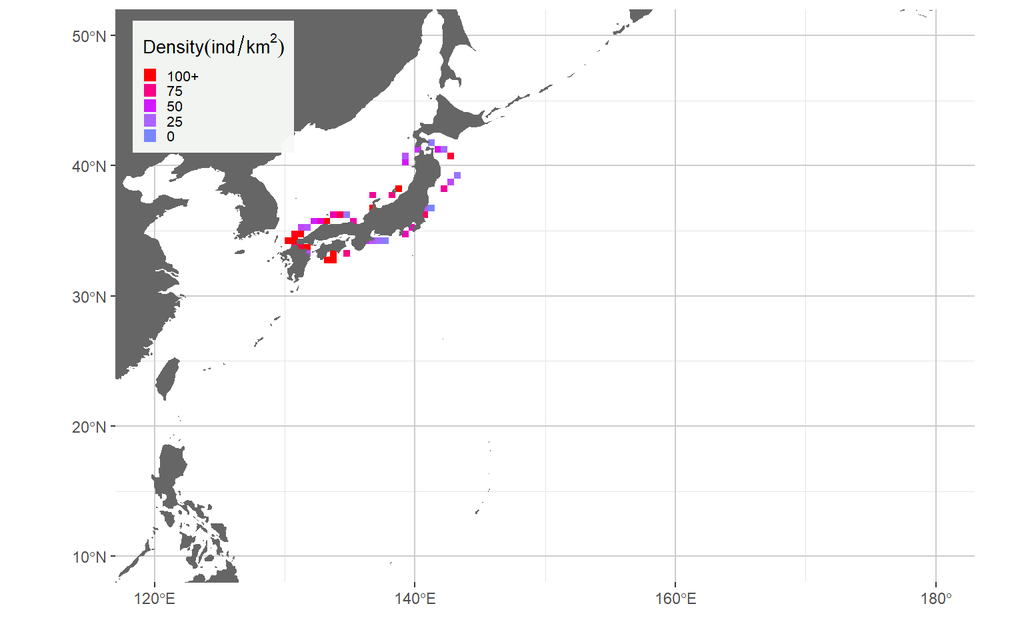

Figure 14: gridごとの密度推定結果(天然物)

```r
 grid.D.plot(Natural.grid)
```

### 9.2.3 area

```r
area.D(Artificial.leg)
```

```
## $area.density
##    Area    Density Total.Length
## 1     1        NaN      0.00000
## 2     2        NaN      0.00000
## 3     3        NaN      0.00000
## 4     4   7.500576     32.70094
## 5     5  50.757654    254.49150
## 6     6  41.979273    183.07380
## 7     7  44.190659    234.70557
## 8     8        NaN      0.00000
## 9     9 147.810139    110.93061
## 10   10        NaN      0.00000
## 11   11  77.834004    104.52435
## 12   12  50.846878    170.78627
## 13   13        NaN      0.00000
```

[output cut: 19 more lines]

```r
area.D(Natural.leg)
```

```
## $area.density
##    Area   Density Total.Length
## 1     1       NaN      0.00000
## 2     2       NaN      0.00000
## 3     3       NaN      0.00000
## 4     4  15.26223     32.70094
## 5     5  86.05811    254.49150
## 6     6  78.91200    183.07380
## 7     7  47.27352    234.70557
## 8     8       NaN      0.00000
## 9     9 108.39523    110.93061
## 10   10       NaN      0.00000
## 11   11 148.49694    104.52435
## 12   12  42.43476    170.78627
## 13   13       NaN      0.00000
```

[output cut: 31 more lines]